# Rasuwa District Profile

Author

UN Nepal & iMMAP

Modified

September 18, 2026

# Introduction

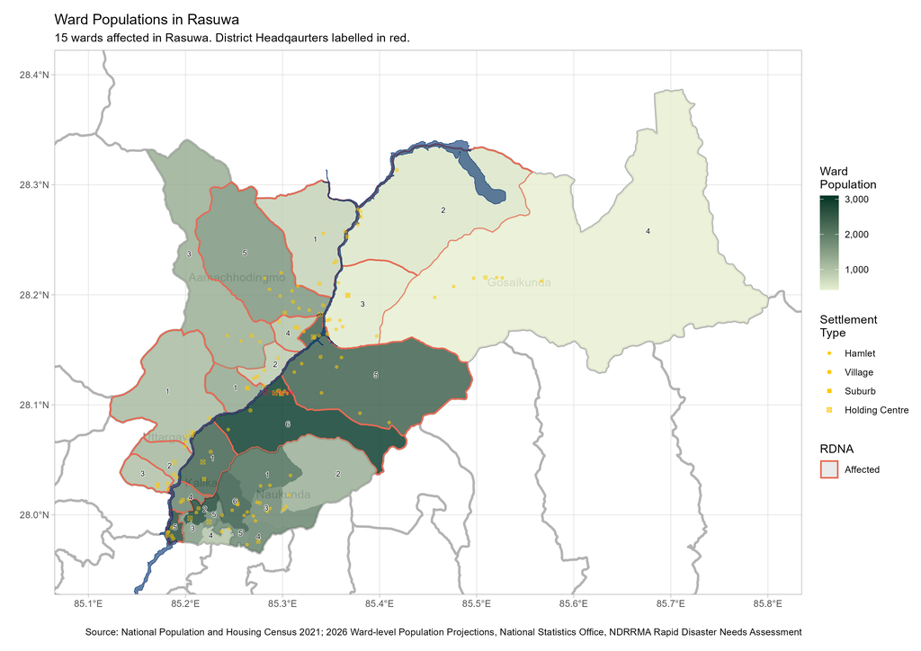

The [population](https://censusresults.nsonepal.gov.np/) of the flood-affected wards in Rasuwa district is 32,436. Of the 27 wards in Rasuwa district, 15 have been affected by the flooding, according to the NDRRMA.

20% (2,225) out of the 11,131 [households](https://censusresults.nsonepal.gov.np/) in Rasuwa are in the poorest quintile of households nationally, in line with the average for Nepal. Of the affected wards, Gosaikunda-1 and Uttargaya-1 are of particular concern, given the particularly high percentages of their populations who are in the poorest quintile nationally.

As of the 2021 Census, there were 1,290 people with disabilities in the district, though it should be noted that this figure relies on self-reporting, so the actual number might be much higher.

Clicking on any of the maps will lead you to a larger version of the map.

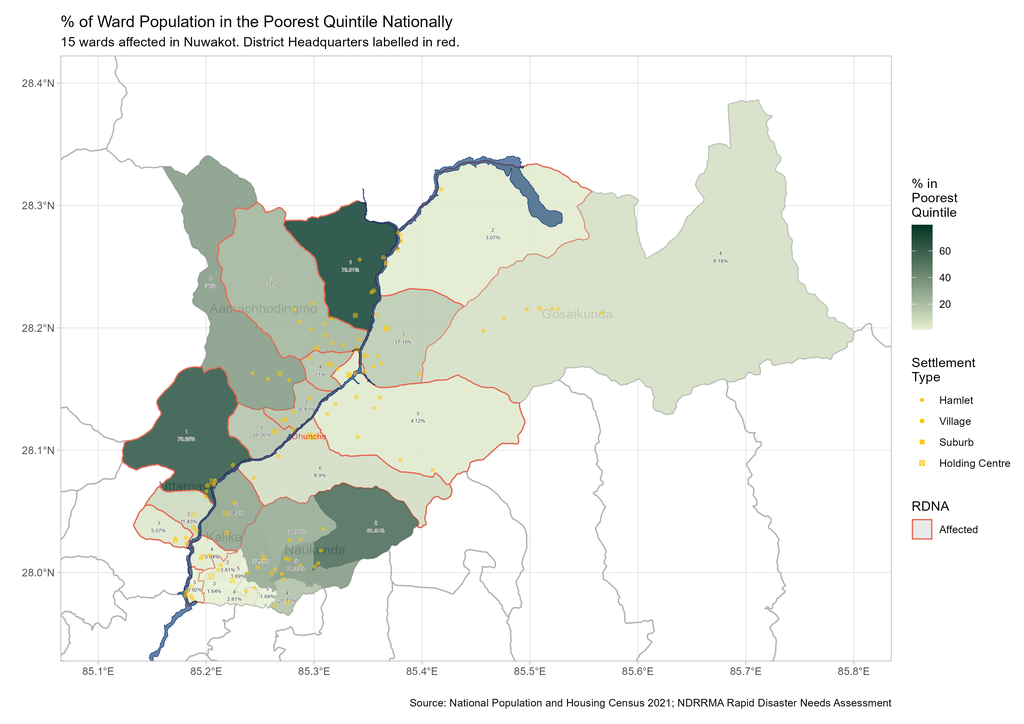

# Needs

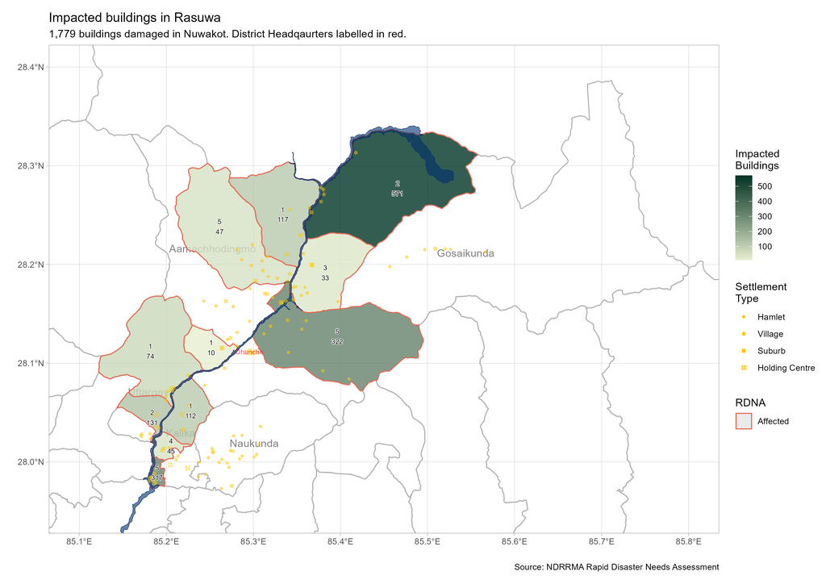

Based on the NDRRMA Rapid Disaster Needs Assessment, 1,779 buildings were damaged in the floods. This damage to housing private buildings has affected 7,634 people.

Gosaikunda-2 received, by far, the most damage to its land area. However, agricultural employment in Gosaikunda-2 was quite minimal at 8% of the employed population. This is in contrast to 46% across the rest of the municipality and 68% for the rest of the district.

It should still be noted that businesses and households in Gosaikunda experienced the most damage and losses out of all the affected municipalities in Rasuwa, with only Bidur reporting greater damage and losses (Bidur’s population is far greater) across all the flood-affected areas.

Economic impacts and losses in Rasuwa, NDRRMA Rapid Disaster Needs Assessment

| municipality | Businesses_affected | Total_damage_incl._households_assets_npr_crore |
| --- | --- | --- |
| Gosaikunda | 338 | 1030.70 |
| Uttargaya | 258 | 411.60 |
| Kalika | 303 | 88.78 |
| Aamachhodingmo | 107 | 37.18 |

## Comparison between districts

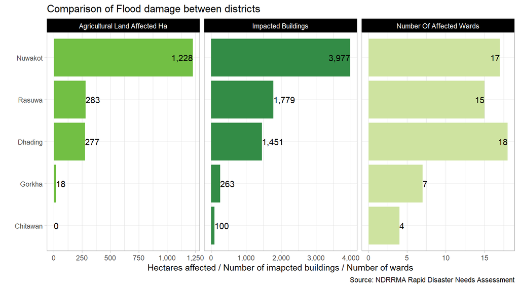

# Response

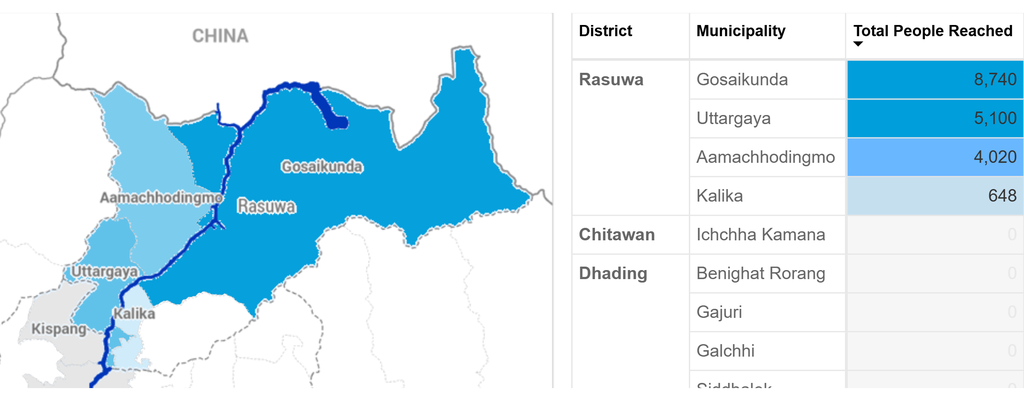

NDRRMA 5Ws 20260917

Gosaikunda has been the focus of response activities in Rasuwa. From the beneficiary frequencies table below (which is inclusive of double counting, and thus indicative of where agencies have focused their resources), we can see that affected persons in Rasuwa have been reached primarily by Food Security and WASH activities.

Clicking on any of the 5W maps and tables will lead to the 5Ws PowerBI dashboard.

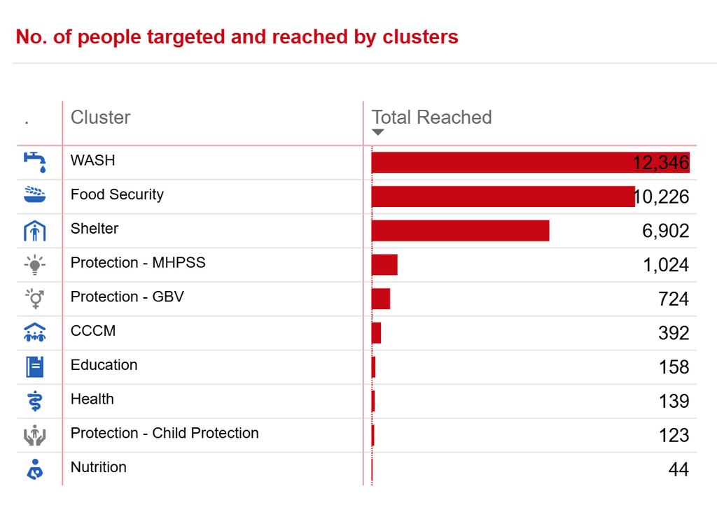

NDRRMA 5Ws 20260917

We still lack more granular data. Almost none of the activities in Rasuwa have been reported at ward level. Uttargaya is the municipality with the best ward-level reporting. 2,958 beneficiary frequencies (inclusive of double counting) have no municipality reported at all. Without ward-level data, it will not be possible to tell on which side of the river activities have occurred.

## Agency presence

Agency presence is highest in Uttargaya, the most accessible part of the district.

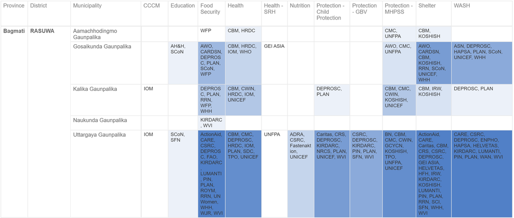

NDRRMA 5Ws 20260917

# References and useful datasets

## Interactive Reference Table

|  | municipality | ward | impacted_buildings | total_households | population_2026 | sex_ratio | population_density | population_2026_male | population_2026_female | total_dependency_ratio | adm3_pcode |
| --- | --- | --- | --- | --- | --- | --- | --- | --- | --- | --- | --- |
| 1 | Gosaikunda | 1 | 117 | 283 | 822 | 103.45 | 12.78 | 422 | 400 | 51.84 | NP0329402 |
| 2 | Gosaikunda | 2 | 571 | 163 | 558 | 114.01 | 3.51 | 296 | 262 | 26.15 | NP0329402 |
| 3 | Gosaikunda | 3 | 33 | 169 | 495 | 99.22 | 9.37 | 251 | 244 | 46.82 | NP0329402 |
| 4 | Gosaikunda | 5 | 322 | 583 | 2518 | 106.17 | 18.87 | 1326 | 1192 | 41.02 | NP0329402 |
| 5 | Aamachhodingmo | 1 | 10 | 311 | 1455 | 102.58 | 83.94 | 734 | 721 | 60.84 | NP0329401 |
| 6 | Uttargaya | 1 | 74 | 293 | 1165 | 98.52 | 15.12 | 555 | 610 | 63.72 | NP0329403 |
| 7 | Uttargaya | 2 | 131 | 315 | 1233 | 91.74 | 84.94 | 569 | 664 | 55.92 | NP0329403 |
| 8 | Uttargaya | 3 |  | 296 | 1080 | 104.22 | 92.21 | 525 | 555 | 51.63 | NP0329403 |
| 9 | Uttargaya | 4 | 45 | 527 | 1986 | 99.03 | 279.85 | 947 | 1039 | 47.66 | NP0329403 |
| 10 | Uttargaya | 5 | 317 | 757 | 2836 | 97.69 | 669.11 | 1345 | 1491 | 47.82 | NP0329403 |

[output cut: 5 more lines]

## Useful links and datasets

### [Digitised NDRRMA Municipal Damage Tables](https://drive.google.com/drive/folders/1GehdusDNji6HGQGQ6R7cEHNJC3BwwNau?usp=drive_link)

### [5W Dashboard](https://app.powerbi.com/view?r=eyJrIjoiZTQ0MGE1NWEtOWJlMi00YmU4LWFhYjMtMTg0OTRmNTRmMGQ1IiwidCI6IjBmOWUzNWRiLTU0NGYtNGY2MC1iZGNjLTVlYTQxNmU2ZGM3MCIsImMiOjh9)

### [Consolidated Census ward-level household and population](https://drive.google.com/drive/folders/1gNkJJR6Q4psoCrWyBcUyzqL9wcKVVRbb?usp=drive_link)

Variables include a breakdown of housing materials, wealth quintile, school attendance and household WASH.

### [Logistics Cluster Access Map](https://logie.logcluster.org/?op=npl)

Updated regularly.